# PBC simulation

Terry Therneau

# Mimic the bilirubin trajectories

We want to summarize the observed bilirubin trajectories in a parametric way so that we can simulate from them. First, take a look at all those with a bilirubin measured within 7 days of death, something we mention in the book as a concern.

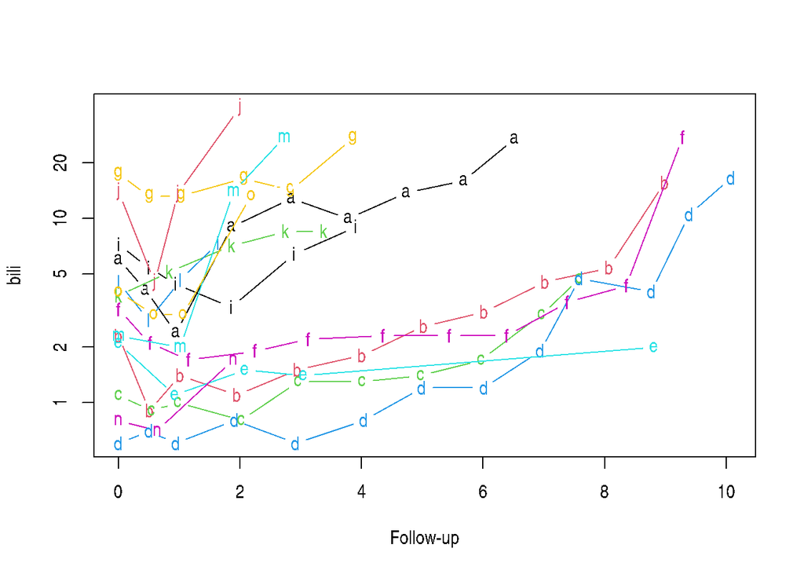

```r
#library(survival)
#library(lme4)
table2 <- function(...) table(..., useNA="ifany")

# Look at all the "just before death" bilirubins
last <- subset(pbcseq, !duplicated(id, fromLast=TRUE))
lateid <- last$id[(last$futime - last$day <=7) & last$status==2]
late <- subset(pbcseq, id %in% lateid)
late$year <- late$day/365.25

plot(bili ~ year, late, log='y', type='n', xlab="Follow-up", ylab="bili")
for (i in 1:length(lateid))
    lines(bili ~ year, late, subset=(id==lateid[i]), col=i%%8, type='b',
          pch=letters[i])
```

```r
names(lateid) <- letters[1:15]
lateid
```

```
##   a   b   c   d   e   f   g   h   i   j   k   l   m   n   o
##  52  57  67  70 106 114 130 138 148 187 220 222 227 239 289
```

Id 57 and 114 (b, f) stand out the most starkly, especially when plotted on aritmetic scale, while for some others there does not appear to be any near death impact (e, k). And what do we make of g? Our 7 day rule is perhaps conservative, removing too many, but that is okay: an ongoing theme is for people to *look* at their data.

The hyperbola fits further down revealed other outliers such as id 200, who has a huge increase 12 days before death.

```r
# This is a copy of code from the book
pdat0 <- subset(pbcseq, !duplicated(id))
pdat0$age10 <- pdat0$age/10
pdat0$bili3 <- cut(pdat0$bili, c(0,1,5,100), c("normal", "1-4", ">4"))
pdat0$agrp  <-  cut(-pdat0$albumin, c(-100, -3.5, -3, 0),
                   c("normal", "3-3.5", "<3"))
pdat0$death <- 1*(pdat0$status ==2)

pdata <- tmerge(pdat0[,c(1,4:6)], pdat0, id=id,
                 death = event(futime, death),
                 options= list(tstart="day1", tstop="day2"))
# I have arbitrarily decided not to make use of any new lab within 7
#  days of death.  This loses 15 bilirubin values.
ptemp <- subset(pbcseq, !(status ==2 & (futime <= (day + 7))))
ptemp$bili3 <- cut(ptemp$bili, c(0, 1, 4, 100), c("normal", "1-4", ">4"))
ptemp$agrp  <- cut(-ptemp$albumin, c(-100, -3.5, -3, 0),
                   c("normal", "3-3.5", "<3"))
pdata <- tmerge(pdata, ptemp, id=id, edema = tdc(day, edema),
                bili= tdc(day, bili), albumin = tdc(day, albumin),
                protime = tdc(day, protime),
                bili3 = tdc(day, bili3), b3= event(day, as.numeric(bili3)),
                agrp  = tdc(day, agrp))

# Now create the multistate dataset using bilirubin groups
# 1. By definition, bilirubin can only change on 'pbcseq' days
# 2. Don't count two visits in the same state as a transition
temp <- with(pdata, ifelse(death, 4,
                           ifelse(as.numeric(bili3)==b3, 0, b3)))
pdata$bstate <- factor(temp, 0:4, c("none", "normal", "1-4", ">4", "death"))
pdata$age1 <- with(pdata, age + day1/365.25)
pdata$age2 <- with(pdata, age + day2/365.25)
pdata$year1 <- pdata$day1/365.25
pdata$year2 <- pdata$day2/365.25
pdata$ibili3 <- pdata$bili3[match(pdata$id, pdata$id)]
check <- survcheck(Surv(year1, year2, bstate) ~ 1, pdata, id=id, istate=bili3)
check
```

```
## Call:
## survcheck(formula = Surv(year1, year2, bstate) ~ 1, data = pdata,
##     id = id, istate = bili3)
##
## Unique identifiers       Observations        Transitions
##                312               1930                435
##
## Transitions table:
##         to
## from     normal 1-4  >4 death (censored)
##   normal      0  90   3    10         77
##   1-4        63   0 107    22         60
##   >4          1  31   0   108         35
##   death       0   0   0     0          0
##
## Number of subjects with 0, 1, ... transitions to each state:
##         count
## state      0   1  2  3  4 5 6
##   normal 259  42 11  0  0 0 0
##   1-4    215  76 18  3  0 0 0
##   >4     215  86  9  2  0 0 0
##   death  172 140  0  0  0 0 0
##   (any)   91  98 70 30 13 5 5
```

```r
count <- table(pdata$id)
round(mean(count>3),2)
```

```
## [1] 0.71
```

```r
table(count)
```

```
## count
##  1  2  3  4  5  6  7  8  9 10 11 12 13 14 15 16
## 27 27 35 42 31 20 19 24 17 24 14 13  5  5  6  3
```

```r
p4 <- subset(pdata, (id %in% names(count)[count>3]))
delta1 <- with(p4, tapply(bili, id, function(x) diff(x[1:2])))
mean(delta1 < 0)
```

```
## [1] 0.4843049
```

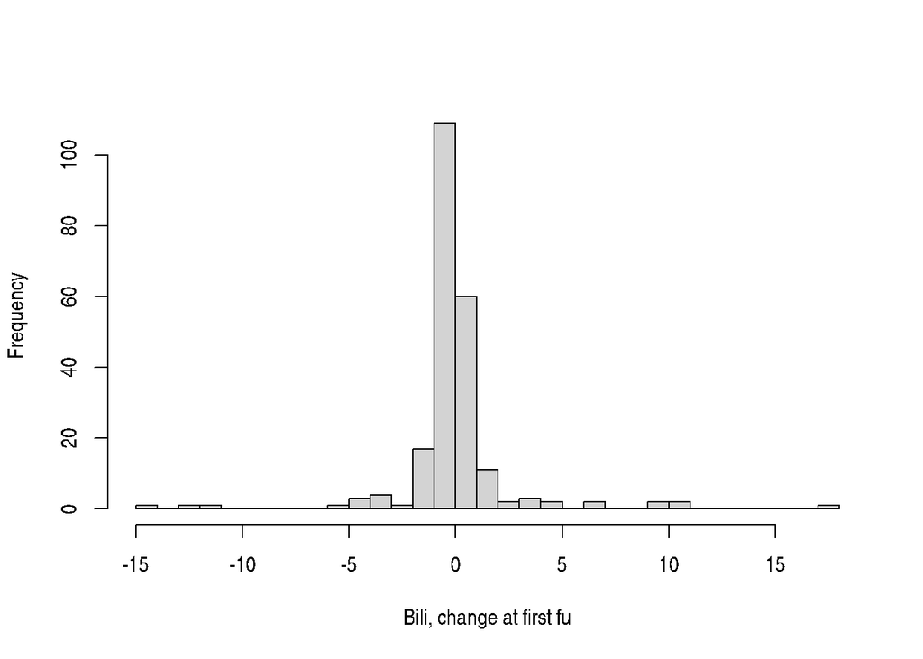

```r
hist(delta1, nclass=30, main=NULL, xlab="Bili, change at first fu")
```

```r
subset(p4, id %in% names(delta1[delta1< -10]), c(id, year1, bili))
```

```
##       id     year1 bili
## 608   75 0.0000000 17.1
## 609   75 0.4982888  4.7
## 610   75 1.0732375  5.4
## 611   75 2.0342231  5.9
## 612   75 2.9514031  6.6
## 979  128 0.0000000 16.2
## 980  128 0.5256674  4.5
## 981  128 0.8514716 18.5
## 982  128 1.8480493 16.5
## 983  128 2.6803559 16.0
## 1101 144 0.0000000 28.0
## 1102 144 0.5010267 13.6
## 1103 144 0.9993155 17.5
## 1104 144 2.3545517 14.1
```

For the simulation, I do not allow for a drop in the true bilirubin. That is, consider a biliogy where the true underlying disease process starts flat and then turns upward, and so does th “true” bilirubin that is driving that process. As our set of prototypes, fit a hyperbola to log(bili), for everyone with 4 or more values. The equation is $y= a + b[(x-c) + \sqrt{(x-c)^2 + .5}]$; $a$ is the starting “flat”, $b$ the right hand slope and $c$ the inflection point. We are essentially using a broken line with a horizontal left hand portion; the hyperbola formula has first and second derivatives so optimizer routines are happier. The .5 causes the curve to take about 1-2 years to fully turn the corner. For a subject with no flat portion, they were already rising at enrollment, the optimum has an inflection at -infinity; this completely removes the bend. But that solution also drives the intercept down to an odd value. The function is essentially flat at -5, so force that as a minimum allowed value for the inflection point, i.e., 5 years before enrollment. This constraint won’t change the RSS much at all, but makes the results look a bit more sane.

```r
hfun <- function(par, x, y, ss=TRUE, positive=TRUE) {
    inflect <- pmax(par[3], -5)
    if (positive) par[2] <- pmax(0, par[2])
    yhat <- par[1] + par[2]*((x-inflect) + sqrt((x-inflect)^2 + .5))
    if (!ss) yhat
    else sum((y-yhat)^2)
}
id4 <- unique(p4$id)
hfit <- matrix(0, length(id4), 6)
for (i in 1:length(id4)) {
    j <- (p4$id== id4[i])
    lfit <- lm(log(bili) ~ year1, p4, subset=j)
#    tfit <- optim(c(coef(lfit), .1), hfun, method="BFGS",  # one subject fails
    tfit <- optim(c(coef(lfit), .1), hfun, method="Nelder-Mead",
                  x= p4$year1[j], y=log(p4$bili[j]))
    hfit[i,] <- c(tfit$par, coef(lfit), sqrt(tfit$val/sum(j)))
}
hfit[,2] <- pmax(0, hfit[,2])  # the "positive" attribute above

toss <- (abs(hfit[,2]) > 1.5)  # this is rather arbitrary, to cut off id 200
toss <- (toss | hfit[,5] < -.25) # linear fit is strong negative
colnames(hfit) <- c("intercept", "slope", "inflect", "lm int", "lm slope", "std")
rownames(hfit) <- id4
hfit[toss,]
```

```
##      intercept    slope   inflect     lm int   lm slope       std
## 126 -0.4093358 3.562218 2.2347358 -0.2480842  0.8642650 0.2881293
## 247  1.4277783 0.000000 0.6574791  2.0966258 -0.7200109 0.5910711
## 311  0.3074642 0.000000 0.3892192  0.7622436 -0.3950723 0.4847087
```

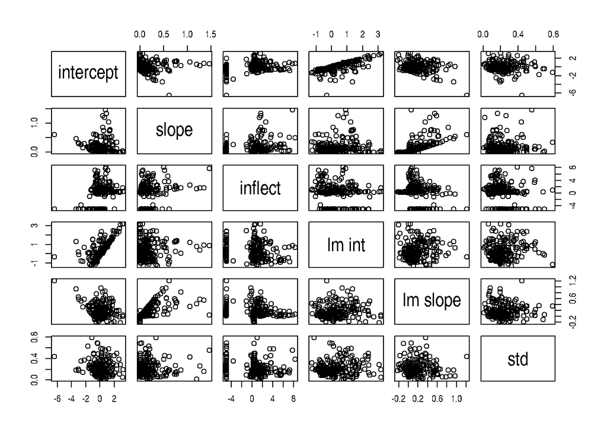

```r
pairs(hfit[!toss,])
```

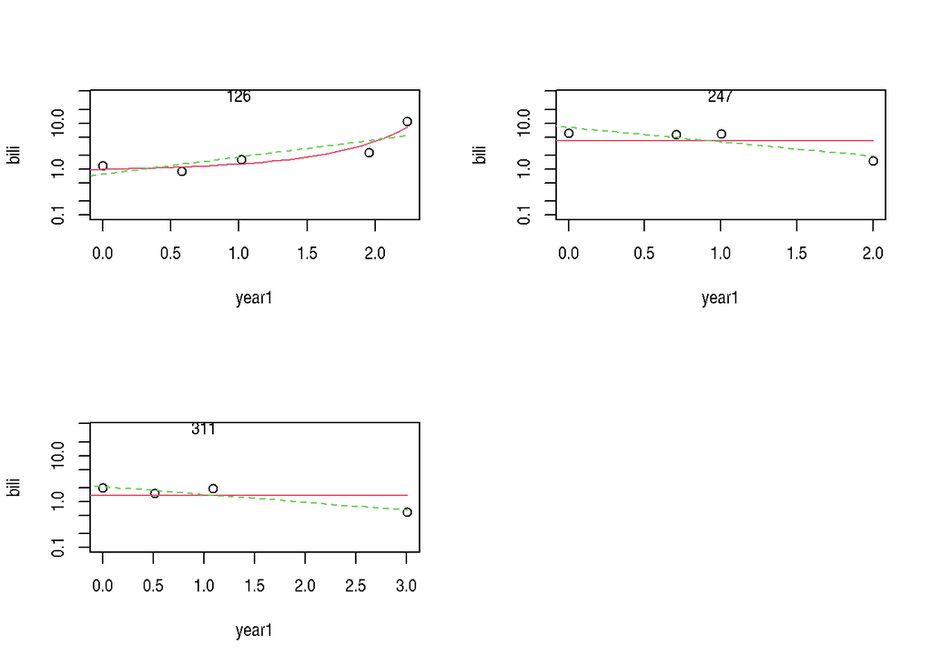

```r
showfit <- function(id){
    i <- match(id, id4)
    tdat <- subset(p4, id==id4[i])
    xx <- seq(-1, max(tdat$year1), length=50)
    yhat <- exp(hfun(hfit[i, 1:3], xx, ss=FALSE))
    plot(bili ~ year1, tdat, log='y', ylim=range(p4$bili))
    lines(xx, yhat, col=2)
    lines(xx, exp(hfit[i,4] + xx*hfit[i,5]), col=3, lty=2)
    text(1, 40, id4[i])
}
opar <- par(mfrow=c(2,2))
for (i in which(toss)) showfit(id4[i])
par(opar)
```

The above shows thes one who will not be used for the simulation. About 0.27 of the fits have an estimated inflection to the left of 0.

```r
temp <- subset(p4, !duplicated(id))
base <-data.frame(id=id4,hfit[,1:3], age= temp$age, bili3=temp$bili3)[!toss,]
# the baseline for the simulant doesn't exactly match temp
zz <- double(nrow(base))
for (i in 1:nrow(base)) {
    zz[i] <- exp(hfun(unlist(base[i,2:4]), x=0, ss=FALSE))
}
base$bili3 <- cut(zz, c(0, 1, 4, 100), levels(temp$bili3))
```

The overall hazard of death and censoring distribution are below.

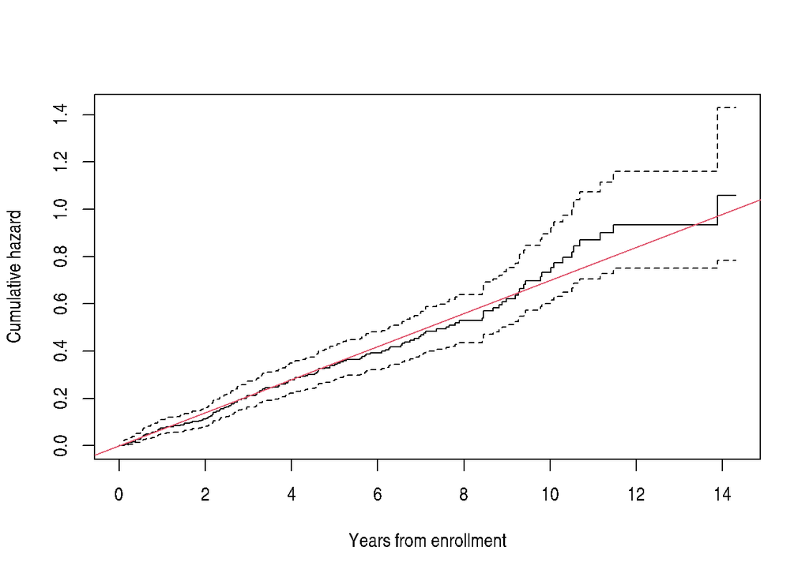

```r
p1 <- subset(pbcseq, !duplicated(id))
dfit <- survfit(Surv(futime/365.25, status==2) ~ 1, p1)
cfit <- survfit(Surv(futime/365.25, status <2)~ 1, p1)
plot(dfit, cumhaz=TRUE,
     xlab="Years from enrollment", ylab="Cumulative hazard")
abline(0, .07, col=2)
```

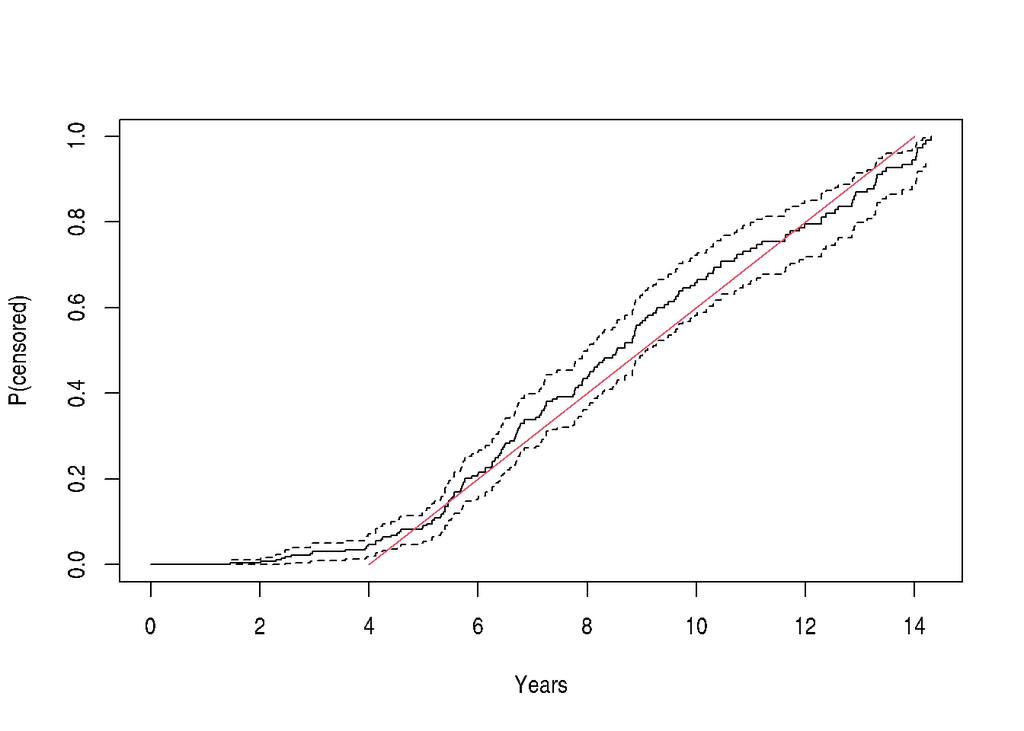

```r
plot(cfit, fun="event", ylab="P(censored)", xlab="Years")
lines(c(4,14), c(0,1), col=2)
```

The death hazard is close to 7%/year, and censoring of U(4,14).

To create a simulation data set we sample with replacement from the set of 220 starting age + bilirubin trajectory sets. This pseudo subject is sampled at intervals, with noise added to the observed bilirubin commesurate with the earlier fits. The true HR is based on enrollment age, true bilirubin, and chosen coefficients; a scale factor turns this into absolute risk based on actual (time dependent) age. This results in a random survival time + random censoring pair, which truncates the followup for that observation.

To next section is almost an aside. I had thought to use Minnesota survival times a scalar as the baseline absolute risk, but that wasn’t really a good idea (efit, efit2). Then finally got the right idea in efit3.

```r
expected <- survexp(futime ~ 1, data=pdat0, method="individual.h",
                    ratetable=survexp.mn,
                    rmap=list(sex="female", year=as.Date("1976-01-01"),
                              age = round(age*365.25)))
efit <- glm(I(status==2) ~ age + log(expected), poisson, data=pdat0)
coef(efit)
```

```
##   (Intercept)           age log(expected)
##   -5.07570996    0.05420796   -0.36904402
```

```r
efit2 <- glm(I(status==2)~ offset(log(expected)), poisson, data=pdat0)
coef(efit2)
```

```
## (Intercept)
##    2.413935
```

```r
tage <- tcut(pdat0$age*365.25, 1:90 *365.25) # per year of age
expdata <- pyears(Surv(futime, status==2) ~ tage+ bili3, data=pdat0,
                  ratetable=survexp.mn, data.frame=TRUE,
                  rmap=list(sex="female", year=as.Date("1976-01-01"),
                            age = round(age*365.25)))$data
expdata$age <- as.numeric(expdata$tage) # age divided in years
efit3 <- glm(event ~ age + bili3 + offset(log(pyears)), poisson, data=expdata)
coef(efit3)
```

```
## (Intercept)         age    bili31-4     bili3>4
## -6.08735901  0.04367615  1.18373865  2.39786925
```

The efit3 fit ignores the expected and is a valid way to proceed. A second idea is to use coxph along with the cumulative hazard. In the same way that $F(X) ~ U(0,1)$ when $X$ is a random draw from a distrbution with cumulative distribution function $F$, a random draw from the cumulative hazard has an exponentia(1) distribution. So we could use approx() + random exp draw + the empriical cumhaz to get times. But the coefs of efit3 and pfit are very similar, and the coxph cumhaz is reasonably linear, so it is easier to use the efit3 formula directly. We are trying for a death rates in the same ballpark, not an exact match.

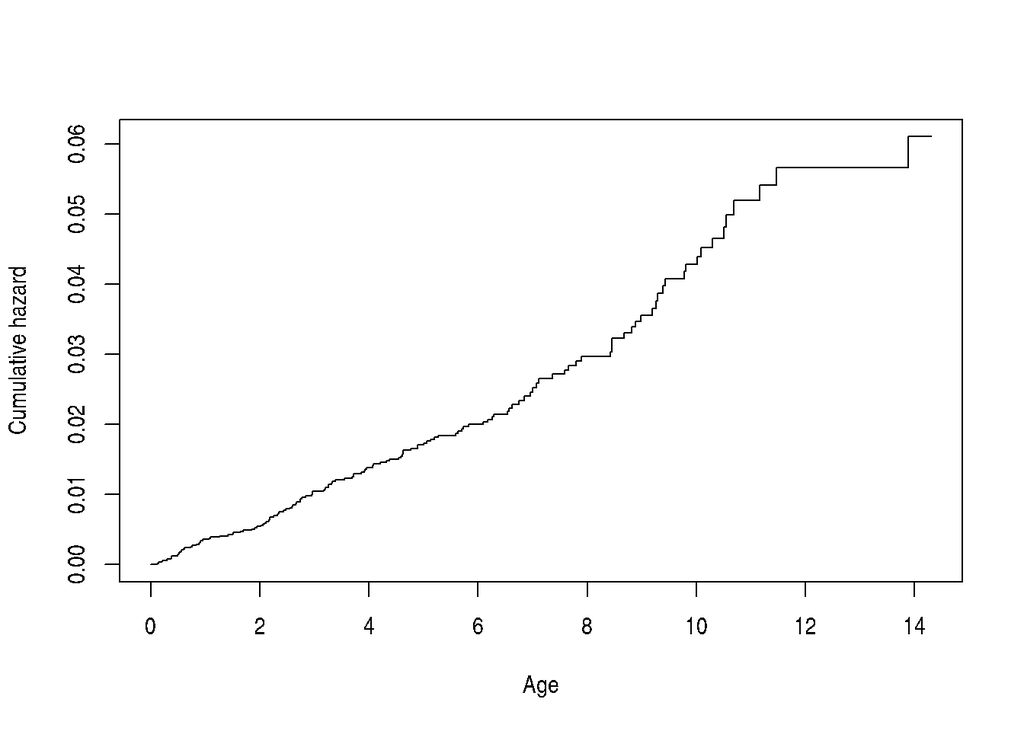

```r
pfit <- coxph(Surv(year1, year2, death) ~ age + bili3, pdata)
psurv <- survfit(pfit, newdata=data.frame(age=30, bili3="normal"),
                 start.time=0)
plot(psurv, cumhaz=TRUE, conf.int=FALSE, xlab="Age", ylab="Cumulative hazard")
```

The simulatation will use continuous bilirubin. In order to facilitate different bilirubin coefficients, we use centered bilirubin, that way if we change the coef the overall death rate doesn’t move so much. Since the real survival will be based on time dependent bilirubin the hazard for any given prototype subject won’t be linear; we track it at monthly discrete times. A monthly step function will be good enough. All the simulations will be censored at 14 years, so 0-14 yrs post enrollment.

```r
meanbili <- mean(log(pdata$bili))
xtime <- seq(0, 14, length= 1+ 14*12)
realsurv <- function(beta, ecoef=coef(efit3)[1:2], debug=FALSE) {
    n <- nrow(base) # number of bilirubin patterns
    hazard <- matrix(0, length(xtime), n)
    for (i in 1:n) {
        lbili <- hfun(unlist(base[i,2:4]), x=xtime, ss=FALSE)
        lbili <- pmin(lbili, log(40))  # .1- 41 is the range in pbcseq
        # log of baseline haz at the start of each month
        bhaz <- ecoef[1] + ecoef[2]*(base$age[i]+ xtime)
        hazard[,i] <- exp(bhaz + (lbili-meanbili)*beta)
    }

    # we want the cumhaz to start at 0
    chaz <- apply(hazard, 2, function(x)
        c(0, cumsum(x[-length(x)]))) * (1/12)  # width of interval
    if (debug) browser()
    exp(-chaz)
}

surv1 <- realsurv(1.3)  #   1.3 = approx coef of TD cox fit using log(bili)
```

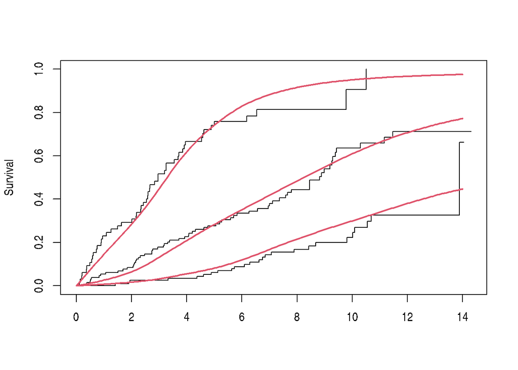

```r
# Compare the margin to the observed KM
temp <- model.matrix(~base$bili3 -1)
margin <- surv1 %*% (temp %*% diag(1/colSums(temp)))
km0 <- survfit(Surv(year1, year2, death) ~ ibili3, pdata, id=id)
plot(km0, fun="event", ylab="Survival")
matlines(xtime, 1-margin, col=2, lwd=2, lty=1)
```

That plot doesn’t look half bad. The marginal rates from our time dependent bilirubin look much like a KM of initial bilrubin. I do worry a bit that the $>4$ group only has 35 canonical cases.

# Simulation

Create simulated data sets where each observation is a random draw from the population of true (starting age, bilirubin over time) sets, for each generate a survival and censoring time, and a set of visit dates. Visit times are based on observed visit intervals. The protocol for the study specified a visit at 6 months and yearly thereafter, below I sample from the observed “time to first” and “time between others” intervals, but capping the interval lengths.

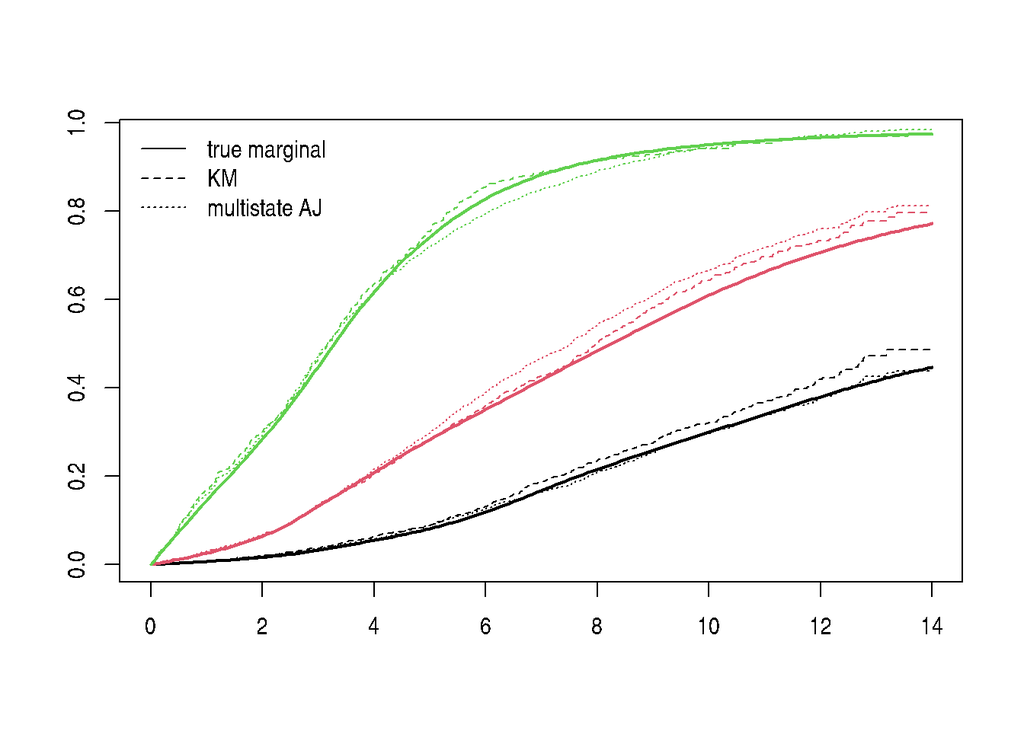

```r
interval1 <- with(pbcseq, unlist(tapply(day, id, function(x) {
    if (length(x) <2) NULL else x[2]-x[1]})))
interval2 <- with(pbcseq, unlist(tapply(day, id, function(x) {
    if (length(x) <3) NULL else (diff(x))[-1]})))

# limit the max
interval1 <- unname(interval1[interval1 < 400])
interval2 <- unname(interval2[interval2 < 1000])

sim1 <- function(k, survmat, id=k, debug=FALSE) {
    # simulate a single subject from prototype k
    visits <- cumsum(c(0, sample(interval1, 1),
                     sample(interval2, 15, replace=TRUE)))/365.25
    ctime <- runif(1, 4, 14)
    # approx will complain in survmat[,k] ends in a string of zeros
    nz <- sum(survmat[,k] >0)
    if (nz < length(xtime)) {
        j <- seq.int(1, nz+ 1L)
        stime <- approx(survmat[j,k], xtime[j], runif(1))$y
    }
    else stime <- approx(c(survmat[,k],0), c(xtime,15),  runif(1))$y
    dtime <- min(ctime, stime)
    death <- 1*(stime <= ctime)
    visit2 <- visits[(dtime > visits)]
    if (any(is.na(visit2)) || is.na(dtime) || length(visit2)==0) browser()

    lbili <- hfun(unlist(base[k, 2:4]), x=visit2, ss=FALSE)  # true bilirubin
    bili  <- exp(lbili) * runif(1, .9, 1.1)        # observed bilirubin
    bili <- pmin(bili, 41) # no outliers
    nrow <- length(visit2)
    bili3 <- cut(bili, c(0, 1, 4, 100), c("normal", "1-4", ">4"))
    # 4 level state
    temp <- ifelse(bili3[-nrow]== bili3[-1], 0, as.numeric(bili3[-1]))
    bstate <- factor(c(temp, 4*death), 0:4,
                     c("none", "normal", "1-4", ">4", "death"))
    if (debug) browser()
    #create a counting process data set for this subject
    data.frame(id=rep(id, nrow), age= base$age[k],
               year1 = visit2, year2=c(visit2[-1], dtime),
               bili = bili,
               bili3 = bili3,
               ibili3 = rep(bili3[1], nrow),
               death = c(rep(0, nrow-1), death),
               bstate= bstate)
}

set.seed(1953)
jj <- sample(1:nrow(base), 4000, replace=TRUE)
temp <- lapply(seq(along=jj), function(i) sim1(jj[i], surv1, id=i))
sdata1 <- do.call(rbind, temp)
scheck <- survcheck(Surv(year1, year2, bstate) ~1, sdata1, id=id,
                    istate=bili3)

km <-  survfit(Surv(year1, year2, death) ~ ibili3, id=id, sdata1)
aj1 <- survfit(Surv(year1, year2, bstate) ~ 1, id=id, sdata1,
                p0=c(1,0,0,0), istate=bili3)
aj2 <- survfit(Surv(year1, year2, bstate) ~ 1, id=id, sdata1,
                p0=c(0,1,0,0), istate=bili3)
aj3 <- survfit(Surv(year1, year2, bstate) ~ 1, id=id, sdata1,
                p0=c(0,0,1,0), istate=bili3)
plot(km, fun='event', col=1:3, lty=2)
lines(aj1[4], lty=3, col=1, conf.int=FALSE)
lines(aj2[4], lty=3, col=2, conf.int=FALSE)
lines(aj3[4], lty=3, col=3, conf.int=FALSE)

matlines(xtime, 1-margin, lwd=2, col=1:3, lty=1)
legend("topleft", c("true marginal", "KM", "multistate AJ"),
       lty=1:3, col=1, bty='n')
```

To summarize: each simulated subject is randomly drawn from a (starting age, bilirubin progression) pattern, there are 220 unique patterns to draw from. For simplicity, each bilirubin pattern is treated as a step function with $14*12 = 168$ steps over the maximum 14 year followup. The true survival for each of the patterns follows a proportional hazards model with
$$\lambda_i(t) = \exp(-6.09 + .044*age + 1.3*(log(bili)-.58))$$

We saw further above that the marginal estimates, which are the mean survival curves for those with initial bilirubin in the $\le 1$, 1–4 and $>4$ groups, look very similar to the KM for those three groups in the `pbcseq` data. That serves to show that our simulation world has some broad similarity to the sequenial PBC data, but detailed mimicry is neither necessary nor something we strived for.

The curves above compare the KM and multi-state AJ curves to the true margin for a single random draw of 4000 subjects. It’s primary purpose is to check for any gross errors in our data generation process.

# Simulation

For the actual simulation we would like to estimate quantiles (5, 25, 50, 75, 95) for the KM, multistate AJ, and multistate coxph approach. We will do this for a sample size of 312, matching the original study. To have reasonable precision in the outer percentiles we will do 1000 simulations, and retain results at the monthly time points.

```r
nsim <- 1000
if (file.exists("simdata.rda")) {
    load("simdata.rda") #simdata1, simdata2
} else {
    # Create the simulation data sets
    set.seed(1960)
    surv1 <- realsurv(1.3)
    surv2 <- realsurv(.6)
    temp <- model.matrix(~base$bili3 -1)
    margin1 <- surv1 %*% (temp %*% diag(1/colSums(temp)))
    margin2 <- surv2 %*% (temp %*% diag(1/colSums(temp)))

    simdata1 <- lapply(1:nsim, function(k) {
        jj <- sample(1:nrow(base), 312, replace=TRUE)
        tdata <-lapply(seq(along=jj), function(i) sim1(jj[i], surv1, id=i))
        do.call(rbind, tdata)
        })

    simdata2 <- lapply(1:nsim, function(k) {
        jj <- sample(1:nrow(base), 312, replace=TRUE)
        tdata <-lapply(seq(along=jj), function(i) sim1(jj[i], surv2, id=i))
        do.call(rbind, tdata)
        })
    save(xtime, simdata1, simdata2, surv1, surv2, base, file="simdata.rda")
}

if (file.exists("curve1.rds")) {
    curve1 <- readRDS("curve1.rds")
} else {
    curve1 <- array(0, dim=c(nsim, length(xtime), 3, 3),
                dimnames=list(NULL, NULL, levels(base$bili3),
                              c("KM", "AJ", "Cox")))
    for (i in seq(along=simdata1)) {
        tdata <- simdata1[[i]]
        km <- survfit(Surv(year1, year2, death) ~ ibili3, id=id, tdata)
        temp <- matrix(1- summary(km, times=xtime, extend=TRUE)$surv, ncol=3)
        curve1[i,,,1] <- temp

        aj1<- survfit(Surv(year1, year2, bstate) ~ 1, tdata, id=id,
                      p0=c(1,0,0,0), istate=bili3)
        temp <- summary(aj1, times=xtime, extend=TRUE)
        curve1[i,,1,2] <- temp$pstate[,4]

        aj2 <- survfit(Surv(year1, year2, bstate) ~1, tdata, id=id,
                       p0=c(0,1,0,0), istate=bili3)
        curve1[i,,2,2] <- summary(aj2, times=xtime, extend=TRUE)$pstate[,4]

        aj3 <- survfit(Surv(year1, year2, bstate) ~1, tdata, id=id,
                       p0=c(0,0,1,0), istate=bili3)
        curve1[i,,3,2] <- summary(aj3, times=xtime, extend=TRUE)$pstate[,4]

        coxfit <- coxph(list(Surv(year1, year2, bstate) ~ 1,
                         0:4 ~ age/common+ shared), tdata, id=id,
                        istate=bili3)

        dummy <- data.frame(age=base$age)
        csurv1 <- survfit(coxfit, newdata=dummy, p0=c(1,0,0,0))
        temp <- summary(csurv1, times=xtime, extend=TRUE)$pstate[,,4]
        curve1[i,,1,3] <- rowMeans(temp)

        csurv2 <- survfit(coxfit, newdata=dummy, p0=c(0,1,0,0))
        temp <- summary(csurv2, times=xtime, extend=TRUE)$pstate[,,4]
        curve1[i,,2,3] <- rowMeans(temp)

        csurv3 <- survfit(coxfit, newdata=dummy, p0=c(0,0,1,0))
        temp <- summary(csurv3, times=xtime, extend=TRUE)$pstate[,,4]
        curve1[i,,3,3] <- rowMeans(temp)
        cat(" ",i)
    }
    saveRDS(curve1, file="curve1.rds")
}

if (file.exists("curve2.rds")) {
    curves <- readRDS("curve2.rds")
} else {
    curve2 <- array(0, dim=c(nsim, length(xtime), 3, 3),
                dimnames=list(NULL, NULL, levels(base$bili3),
                              c("KM", "AJ", "Cox")))
    for (i in seq(along=simdata2)) {
        tdata <- simdata2[[i]]
        km <- survfit(Surv(year1, year2, death) ~ ibili3, id=id, tdata)
        temp <- matrix(1- summary(km, times=xtime, extend=TRUE)$surv, ncol=3)
        curve2[i,,,1] <- temp

        aj1<- survfit(Surv(year1, year2, bstate) ~ 1, tdata, id=id,
                      p0=c(1,0,0,0), istate=bili3)
        temp <- summary(aj1, times=xtime, extend=TRUE)
        curve2[i,,1,2] <- temp$pstate[,4]

        aj2 <- survfit(Surv(year1, year2, bstate) ~1, tdata, id=id,
                       p0=c(0,1,0,0), istate=bili3)
        curve2[i,,2,2] <- summary(aj2, times=xtime, extend=TRUE)$pstate[,4]

        aj3 <- survfit(Surv(year1, year2, bstate) ~1, tdata, id=id,
                       p0=c(0,0,1,0), istate=bili3)
        curve2[i,,3,2] <- summary(aj3, times=xtime, extend=TRUE)$pstate[,4]

        coxfit <- coxph(list(Surv(year1, year2, bstate) ~ 1,
                         0:4 ~ age/common+ shared), tdata, id=id,
                        istate=bili3)

        dummy <- data.frame(age=base$age)
        csurv1 <- survfit(coxfit, newdata=dummy, p0=c(1,0,0,0))
        temp <- summary(csurv1, times=xtime, extend=TRUE)$pstate[,,4]
        curve2[i,,1,3] <- rowMeans(temp)

        csurv2 <- survfit(coxfit, newdata=dummy, p0=c(0,1,0,0))
        temp <- summary(csurv2, times=xtime, extend=TRUE)$pstate[,,4]
        curve2[i,,2,3] <- rowMeans(temp)

        csurv3 <- survfit(coxfit, newdata=dummy, p0=c(0,0,1,0))
        temp <- summary(csurv3, times=xtime, extend=TRUE)$pstate[,,4]
        curve2[i,,3,3] <- rowMeans(temp)
        cat(" ",i)
    }
    saveRDS(curve2, file="curve2.rds")
}
```

Plot the results of the simulation.

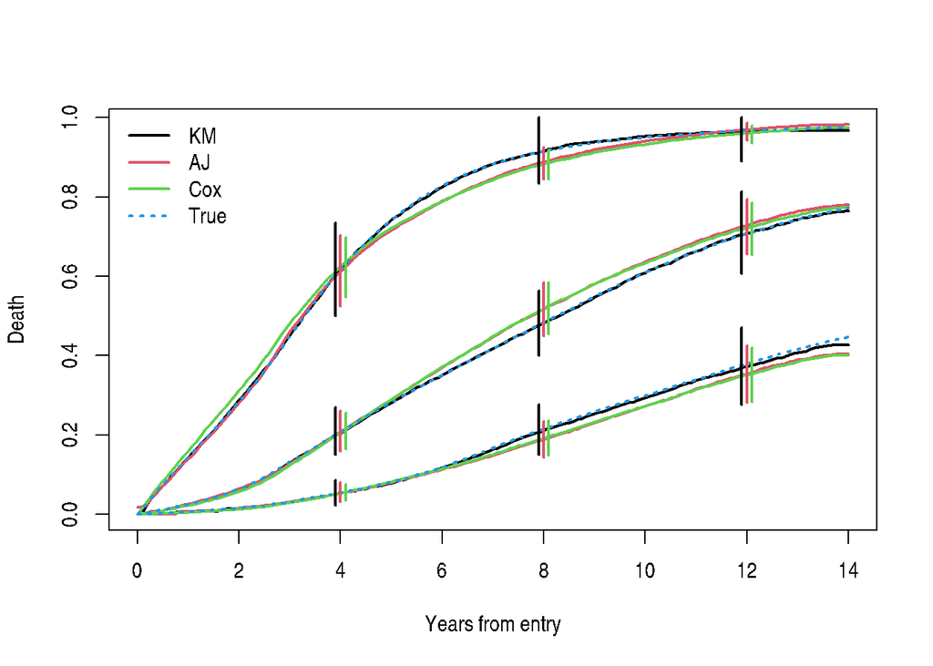

```r
qcurve1 <- apply(curve1, 2:4, function(x) quantile(x, c(.05, .1, .25, .5, .75,
                                                      .9, .95)))
matplot(xtime, matrix(qcurve1[4,,,], ncol=9), type='l', lwd=2,
        col=rep(1:3, each=3), lty=1,
        xlab="Years from entry", ylab="Death")

legend("topleft", c("KM", "AJ", "Cox", "True"), col=1:4,
       lty=c(1,1,1,3), lwd=2, bty='n')

temp <- model.matrix(~base$bili3 -1)
margin1 <- surv1 %*% (temp %*% diag(1/colSums(temp)))
margin2 <- surv2 %*% (temp %*% diag(1/colSums(temp)))
matlines(xtime, 1-margin1, lwd=2, col=4, lty=3)

citime <- c(4, 8, 12)
eps <- .1
ii <- match(citime, xtime) # row index
ciq <- qcurve1[c(1,7),ii,,]
xx <- outer(citime, c(-eps, 0, eps), '+')
for (i in 1:3) {
    segments(xx[,i], ciq[1,,,i], xx[,i], ciq[2,,,i], col=i, lwd=2)
}
```

This plot can almost certainly be improved. Maybe as a 3 panel version?

How is the bias when the bilirubin effect is smaller?

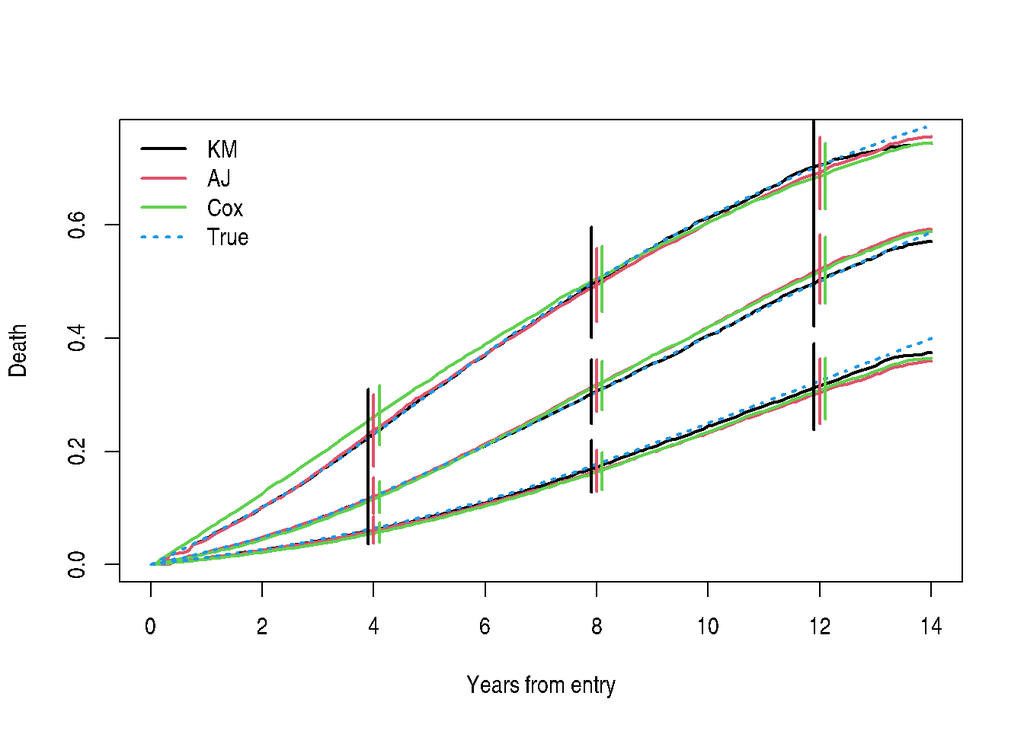

```r
qcurve2 <- apply(curve2, 2:4, function(x) quantile(x, c(.05, .1, .25, .5, .75,
                                                      .9, .95)))
matplot(xtime, matrix(qcurve2[4,,,], ncol=9), type='l', lwd=2,
        col=rep(1:3, each=3), lty=1,
        xlab="Years from entry", ylab="Death")

legend("topleft", c("KM", "AJ", "Cox", "True"), col=1:4,
       lty=c(1,1,1,3), lwd=2, bty='n')

matlines(xtime, 1-margin2, lwd=2, col=4, lty=3)

citime <- c(4, 8, 12)
eps <- .1
ii <- match(citime, xtime) # row index
ciq <- qcurve2[c(2,6),ii,,]
xx <- outer(citime, c(-eps, 0, eps), '+')
for (i in 1:3) {
    segments(xx[,i], ciq[1,,,i], xx[,i], ciq[2,,,i], col=i, lwd=2)
}
```

Because of graphical overlap, the above has the (.1, .9) bars rather than (.05, .95). This can certainly be fixed.